# Final Project MXB262

Sabari C S

2024-06-03

[figure not shown]

# Introduction

In this golden era of football,the debate around who is the greatest player between Lionel Messi and Cristiano Ronaldo.The title for the best is still not decided among these two legends. Over the last decade, the debate has been increased by their extraordinary achievements,contrasting playing styles and clubs they are playing.

The report aims to visually analyse their football achievements, consistency and other attributes of Leo Messi and Cristiano Ronaldo through series of data visualizations. From these visualizations,readers can compare the players attributes and their skills.Then, they can come to a conclusion that who is better player of this decade.

```r
#reading the data
combined_data <- read.csv("players_21.csv")

# Filter the data for Messi and Ronaldo
new_data <- combined_data %>%
  filter(short_name %in% c("L. Messi","Cristiano Ronaldo"))
#Filtering the needed attributes of the player
messi<-new_data%>%dplyr::select(short_name, pace, shooting, dribbling, defending, physic,club_name,nationality,team_position)
messi
```

```
##          short_name pace shooting dribbling defending physic    club_name
## 1          L. Messi   85       92        95        38     65 FC Barcelona
## 2 Cristiano Ronaldo   89       93        89        35     77     Juventus
##   nationality team_position
## 1   Argentina           CAM
## 2    Portugal            LS
```

```r
#Changing the data for the Radar plot
players_long <- messi %>%
    pivot_longer(cols = -c(short_name,club_name,nationality,team_position), names_to = "attribute", values_to = "value")

# Define a function for the customized tooltip for the radar chart to show the club,nationality,position and attributes
tooltip_content <- function(name, attribute, value, club, nationality, position) {
  paste0("<b>", name, "</b><br>",
         "<b>Attribute:</b> ", attribute, "<br>",
         "<b>Value:</b> ", value, "<br>",
         "<b>Club:</b> ", club, "<br>",
         "<b>Nationality:</b> ", nationality, "<br>",
         "<b>Player Positions:</b> ", position)
}

# Create the interactive  radar chart for comapring messi and ronaldo attributeaasssa
messi_vs_ronaldo <- highchart() %>%
  hc_chart(polar = TRUE, type = "line") %>%
  hc_title(text = "Attributes Comparison: Messi vs Ronaldo") %>%
  hc_xAxis(categories = unique(players_long$attribute), tickmarkPlacement = "on", lineWidth = 0,gridLineColor = "black") %>%
  hc_yAxis(gridLineInterpolation = "polygon", lineWidth = 2, min = 0, gridLineColor = "black") %>%
  #Adding the data of Messi
  hc_add_series(
    name = "L. Messi",
    data = players_long %>% filter(short_name == "L. Messi") %>% pull(value),
    tooltip = list(
      pointFormat = tooltip_content( "L. Messi","{point.category}","{point.y}",
        unique(new_data$club_name[new_data$short_name == "L. Messi"]),
        unique(new_data$nationality[new_data$short_name == "L. Messi"]),
        unique(new_data$team_position[new_data$short_name == "L. Messi"])
      )  # Customize tooltip content
    )
  ) %>%#Adding the data of Messi
  hc_add_series(
    name = "C. Ronaldo",
    data = players_long %>% filter(short_name == "Cristiano Ronaldo") %>% pull(value),
    tooltip = list(
    pointFormat = tooltip_content( "C. Ronaldo","{point.category}","{point.y}",
        unique(new_data$club_name[new_data$short_name == "Cristiano Ronaldo"]),
        unique(new_data$nationality[new_data$short_name == "Cristiano Ronaldo"]),
        unique(new_data$team_position[new_data$short_name == "Cristiano Ronaldo"])
      )
    )
  ) %>%
  hc_add_theme(hc_theme_google())%>%
  hc_caption(text = "Click the each player's name to see their atrributes individually", align = "center", verticalAlign = "bottom", style = list(fontSize = "12px"))
#Plotting the radar chart
messi_vs_ronaldo
```

[interactive chart not shown]

## Visualisation 1

**Main Message**

The main message of this visualization is to compare the players Leo Messi and Cristiano Ronaldo according to their various attributes. The variables chosen for this visualization is defending,shooting,dribbling,pace and physic.The reason for analyzing these individual attributes is that we can find out how the impact of their in team.Moreover,this helps to identify each player’s strength and weaknesses.

Variable explanation:- Defending :- It shows the defensive skills of the player in a game. Dribbling :- It shows the ball controlling abilities and take the ball past opponents with slight touches. Pace :- It shows the speed of the player. Physic:-It shows the strength of a player. Shooting : It shows the accuracy and power while hitting a football.

**Critical evaluation of the plot**

Source:- I sourced the data for this visualisation from Kaggle.(https://www.kaggle.com/datasets/stefanoleone992/fifa-21-complete-player-dataset). This dataset contains details of more than 11000 players in FIFA and so many attributes like age, weight,value and so on.

The primary audience of this data visualization are sport enthusiasts, sport reporters, sport analysts,Soccer teams.In addition, this visualization provide more detailed information, so it could attract general public interested in football.

Action:- * It helps the sport enthusiast and sport analysts to know detailed information about Lionel Messi and Cristiano Ronaldo about their individual attributes. * It helps the soccer team to recruit player to their team according to their individual attributes. * General public can understand more information about these player like nationality, club and so on.

All the information is given in a interactive chart,the different colors of the pentagon represent the each player gets the initial attention of the reader.Then,the information can read in any order like choosing which attribute/player to select first.It is a reader-driven chart.

The data has been displayed using data points.Each point shows different attributes of the player.Different colored polygon is used represent the different player.Additionally, added a hover feature to the visualization to add more information about player.

**Justification of Plot type**

Radar chart is chosen for plotting the data.It is one of way to effectively visualize the higher dimensional data. This data contains multiple variables to visualize, so radar plot effectively shows multiple variables. Attributes has plotted against along the axes of the chart.By clicking each polygon, reader can gain more information about the player and it make the reader more engaging.It displays the data more clearly. Reader can analyze each player individually by clicking the name of each player.Also, it enables the reader to make comparisons side by side.This plot prompt the audiences to remember the message and it is accessible to the general audience.

In this visualization, preattentive attributes used in this visualization is color to to distinguish between the player. Proper title given to the plot, so the readers can know content of the plot.Interactivity helps give more information to the reader and it makes the visualization more engaging.Those who interested to analyse attributes of each player individually they can use the filter option. For more visual accuracy, changed the grid line color to black.

**Roadblocks**

- Finding the reliable dataset:- Choosing the appropriate dataset was one of the major roadblock faced while making this graph.Accurate and reliable data is important aspect we need while making a visualization because unreliable data can lead to misleading comparisons
- Choosing Relevant variables from the dataset:- This dataset contains numerous attributes of a player,so we need to choose relevant attributes for comparison. For example, we are comparing two strikers in this visualization so comparing attributes like clearing,gk_catching and so on are irrelevant.We can’t able to comapre these players.
- Selecting the suitable plot:- Ensure that our chart should convey the information correctly.Some charts will not serve our message well like comparisons and also make clutters. So selecting a suitable plot is major challenge faced

**Recommendations**

- Including advanced interactive options:- In this visualization, there are some features like interactive is already included but use of that is limited. Implementing advanced filtering options enables the user to access the attributes they are interested and compare the performance of Messi and Ronaldo according to they want.

*Including performance of player over time:- Adding a time series plot into the tool tip that each attribute changed over the time period. It helps the reader to understand more about that particular attribute of the plot.

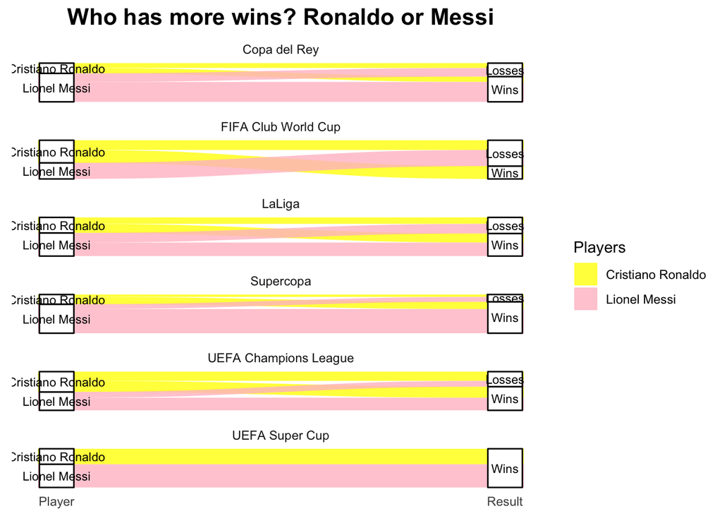

```r
#reading the data
data_2<-read.csv("Messi vs Ronaldo.csv")
#Removing the zero from the results
df <- data_2 %>% mutate(Result = gsub(":0", ":", Result))
##creating a new column that shows match won,loss or draw according to the Result
df <- df %>%
  mutate(Goals_Scored = as.numeric(substring(Result, 1, 1)),
         Goals_Conceded = as.numeric(substring(Result, 3, 3)),
         W_D_L = case_when(
           Goals_Scored > Goals_Conceded ~ "Win",
           Goals_Scored < Goals_Conceded ~ "Loss",
           TRUE ~ "Draw"
         ))
#Filtering the competitons where both messi and ronaldo played.
df<-df %>%
  filter(Player %in% c("Lionel Messi", "Cristiano Ronaldo")) %>%
  group_by(Competition) %>%
  filter(n_distinct(Player) == 2) %>%
  ungroup()
df<-df%>%dplyr::select(Player,Competition,Result,W_D_L)
#Counting the number of Wins,Losses and Draws
data<-df%>%
    group_by(Player, Competition) %>%
    summarise(Wins = sum(W_D_L == "Win"),
       Losses = sum(W_D_L == "Loss"),
         Draws = sum(W_D_L == "Draw") )
#Converting the data to a longer format
alluvial_data<-data%>%pivot_longer(cols = -c(Player,Competition))
#filtering that shows only Wins and Losses
final_data<-alluvial_data%>%filter(name%in%c("Wins","Losses"))
#Plotting the alluvial plot
ggplot(final_data, aes(y = value, axis2 = name, axis1 = Player)) +
  geom_alluvium(width = 1/12, aes(fill = Player), alpha = 0.8) +
  geom_stratum(width = 1/13) +  # arranging the width of the stratum (axes)
  geom_text(stat = "stratum", aes(label = after_stat(stratum)), size = 3, hjust = 0.5, vjust = 0.5) +  # labeling each axes
  scale_x_discrete(limits = c("Player", "Result"), expand = c(0.05, 0.05)) +
  scale_fill_manual(values = c("Cristiano Ronaldo" = "yellow", "Lionel Messi" = "pink")) +  # Assign colors to players
  theme_minimal() +
  facet_wrap(~ Competition, scales = "free_y", ncol = 1) +#faceting according to the competition
  labs(fill = "Players", y = "", title = "Who has more wins? Ronaldo or Messi") +
  theme(
    axis.text.y = element_blank(),
    axis.ticks.y = element_blank(),
    panel.grid = element_blank(),
    plot.title = element_text(hjust = 0.5, size = 16, face = "bold"),
    axis.title.x = element_blank(),
    panel.spacing = unit(0.5, "lines"),
    axis.title.y = element_blank()
  )
```

# Visualisation 2

**Main Message**

The main message of this visualization is to compare the head to head performance of Messi and Ronaldo in different competitions they played together.This visualization analyses the wins and losses of these players in different famous football leagues. Moreover, we can analyse the impact of them in their teams and also it shows the difference in their performance in same competitions.

I sourced this dataset from Kaggle(https://www.kaggle.com/datasets/azminetoushikwasi/lionel-messi-vs-cristiano-ronaldo-club-goals). It contains a huge amount of data about the matches played by Messi and Ronaldo in their career like opponent, who assisted, current club, match type(quarter final, semi final and so on) and some more information about the matches.

**Critical evaluation of the structure**

The primary audiences of this visualization are sport enthusiasts, sport analysts and soccer team. Also, it is useful for general public who is interested in football. Action:- * It helps the soccer team to take decision like include that player in team on the particular competition. * Football fans analyse the head to head performance of the favourite player in the famous leagues. * Sports analysts can make comparisons of about messi and ronaldo in different competitions.

The data is given in an alluvial plot(static image ). The primary attention of the reader goes to two different color in the visualizations.Viewers will quickly identify the flow to each axes in the plot and they can compare the players performance in different leagues.(Author-driven)

In the alluvial plot,the axes shows the different players and the outcome of certain number of matches.Then, the size of the flow shows the count of wins and Losses. The legend helps to understand the data more clearly.

**Justification of the plot type**

Alluvial plots is one of the best way to show the flow of quantity of between different levels and it depicts multi dimensional data effectively. It effectively shows the flows of wins and loses in different competitions played by Cristiano and Leo. This plot is also effective way make comparisons between the players simultaneously. Alluvial plot simplify the complex data available in the real world and make it easier to understand for the readers. It is more visually engaging and gain audience’s attention effectively than some other plots.

**Roadblock**

- Filtering the dataset :- Wrangling the dataset was the main roadblock faced in the visualization process.The data must accurately presented to the readers.The dataset is contains the information in different format.It is critical to overcome this because present the without filtering can mislead the audience and it not convey the message clearly.
- Making the visualization easier to interpret for the general audience :- Making the visualization accessible for a wider audience like people who are not that much familiar football.In visualization a good title is given for better understanding about the plot. Improving it accessibility will enhance it impact and reach.

**Recommendations**

- Interactive features :- Including the advanced interactive features like filtering tools will increase the quality of visualizations. For example, filtering according to particular competition and more details about that league and players performance will attract more general audience. Interactive features will make the audience more engaging and gain more information.
- Implementing real time data updates:- Implementing real time data updates for the visualization would improve the quality and readers can understand the current trends. We can use the visualization for a long time if we implement real time data updates.

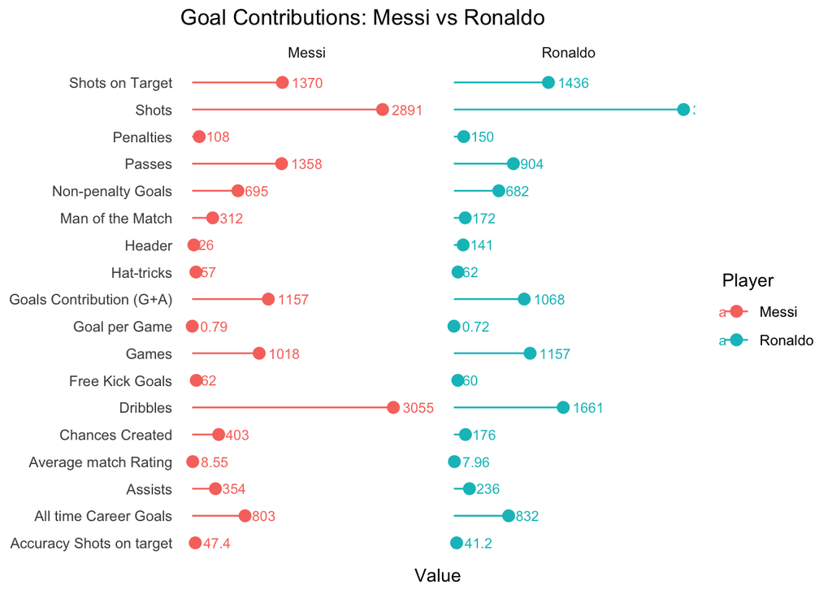

```r
#reading the data
player_stat <- read_excel("Messi vs Ronaldo Stat.xlsx",sheet = 5)
#Converting the data into a longer fromat
player_stat_long<-player_stat%>%pivot_longer(cols = -c(Factors))

#making the lollipop plot
ggplot(player_stat_long, aes(x = Factors, y = value, color = name, label = value)) +
  geom_segment(aes(x=Factors,xend=Factors,y = 0,yend=value))+
  geom_point(size = 3) +
  labs(title = "Goal Contributions: Messi vs Ronaldo",
       x = "Factors",
       y = "Value",
       color = "Player") +
  geom_text(hjust = -0.3, size = 3)+
  theme_minimal() +
  coord_flip()+
  theme(panel.grid.major = element_blank(),
    panel.grid.minor = element_blank(),
    axis.text.x  = element_blank(),
    axis.title.y = element_blank()
  )+facet_wrap(~name)
```

#Visualisation 3

**Main Message**

The best player in football can be find out by analyzing numerous factors but the main factor is their achievements throughout their career and their consistency. This visualization shows the goal contributions and overall performance of two great football legends, Messi and Ronaldo. This visualization shows the career achievements and difference between some of the key attributes.

The dataset used for this visualization is sourced from Kaggle(https://www.kaggle.com/datasets/ogbuzurukelechi/messi-vs-ronaldo-dataset).This dataset contains many data about the performance of Messi and Ronaldo like the awards they got in their career, all time careers goal and assists, their world cup performance and their club performance.

**Critical evaluation of structure**

The primary audiences of this visualization are sport authorities like FIFA,CONIFA and so on, sport enthusiast and analysts. Action:- * Sports authorities like FIFA can take decisions about awards based on their career performance like Super Ballon d’or. * Sports enthusiasts can understand who performed better in their career. * Sports analysts can get informations about Messi and Ronaldo performance

The data is visualized in a lollipop plot.All information is given in static image. Colour has been used for show the different player, so the primary attention goes to lollipop in the chart and then, reader analyses the different performance metrics.

In the lollipop chart, the y axis shows the different career achievements of each players.The chart is faceted into two for representing stats of each player and different color is also given to each player to make more visually clear.

**Justification for plot type**

A lollipop plot is chosen for visualize this data. It enables the reader to effectively compares the performance of messi and ronaldo across various attributes.Lollipop chart is more clean when compare to bar chart, so it reduce overlap of the variable and this data contains many factors, so ploting the data in a bar chart don’t show the data point clealrly. The lollipop chart is easy interpret, so attracts more audience with less statistical knowledge.

Preattentive attributes

- Color:- Color is used to represent the two different players.It helps the reader can quickly compare the players.
- Length :- Length is used to show size of factors.It is an effective way to show quantitative data , so reader can easily intrepret the data
- Size:- The dot is at the end of the line is a pre attentive attribute.That dot immediately draws the attention of the reader.
- Labels:- Labeling the value at the end of the dot shows the value of each factor, so reader can get the precise information.

The plot has been faceted into two to reduce clutter and helps to compare easily.Labelling the values in the each bar enables us to reduce the data to ink ratio by removing the grid lines.

**Roadblock**

- Selecting the plot type :- Selection of plot type is very important in this visualization.If the choice is bad, reader can’t interpret the data properly.For example, plotting this data in a bar plot can cause clutter because there any many variables in this and reader can’t understand everything clearly.

**Recommendation**

- Interactive feature:- This dataset contains many data about career like individual performance,club performance and so on. This visualization only shows overall career performnce. Including filtering option according to the different table(excel sheet) in the dataset will be helpful for the reader. They can make comparisons in different ways. For example, some football fans says Ronaldo’s performance in world cup is bad compared to messi, so these option the reader can compare messi and ronaldo world cup performance.
- Integrating a line chart into same plot:- Including a line chart into the same plot like on top the bar that showing the goal scoring consistency of messi and ronaldo. This helps to understand their performance in different years. They can understand who is more consistent player.